# Banned Books - At Least We’re Not Burning Them

Lucas Deese, Amber Wolf, Enrique Espinonsa, Alexis Shermett

2025-03-31

# Overview

## Question

Our initial question was to see if we could find patterns surrounding the banning of books in schools around the United States (although we focused on the continuous U.S.). The question was intentionally broad, allowing us to look at everything from political information to book content. In the end, we ended up looking at which states had the most bans, what words were more frequently in the descriptions of banned books, the state political leaning and the banning of books, along with what genres were more frequently banned.

## Data

We used a number of datasets, 8 in total, from 3 different sources, to answer our various questions. 3 of our datasets are sourced from Pen America, where we got their banned books datasets for the [2021-2022 academic year](https://pen.org/book-bans/banned-book-list-2021-2022/), the [2022-2023 academic year](https://pen.org/book-bans/2023-banned-book-list/), and the [2023-2024 academic year](https://pen.org/book-bans/pen-america-index-of-school-book-bans-2023-2024/). These three datasets were the foundation of our project, and contained everything from the source of the challenge to the status of the book to the counties within the states they were challenged in. We didn’t exhaust the possibilities of the dataset, but I think we came close. Added onto this were the 4 datasets from the [National Conference of State Legislatures](https://www.ncsl.org/about-state-legislatures/state-partisan-composition), comprising of the 4 years that were covered in the Pen datasets. These datasets had the majority political party in the legislature and government of each state for all four years. Lastly, our [Kaggle](https://www.kaggle.com/datasets/chielerli/banned-book-dataset?resource=download) dataset contained descriptions for many of the books in the Pen dataset. This data set also included genres that the book was considered.

## Data cleaning

The cleaning of this dataset was a rather arduous process, undertaken by Lucas. Lucas did all of the work in cleaning the data to be used for the rest of the project.

# The Work

## Cleaning Process

First, we had to load the data into the project. As we were using Github to share our progress, Amber, when combining all of our code into one file, changed any personal computer locations to pull from the github instead. This allowed for us to then make any final changes without having to change where the data was being pulled from, along with making it so that everything was not being downloaded on 4 different computers.

```r
p1_2 <- read.csv("https://raw.githubusercontent.com/TheSillypants/BannedBooks/refs/heads/main/PEN%20America's%20Index%20of%20School%20Book%20Bans%20(July%201%2C%202021%20-%20June%2030%2C%202022)%20-%20Sorted%20by%20Author%20%26%20Title.csv")

p2_3 <- read.csv("https://raw.githubusercontent.com/TheSillypants/BannedBooks/refs/heads/main/PEN%20America's%20Index%20of%20School%20Book%20Bans%20(July%201%2C%202022%20-%20June%2030%2C%202023)%20-%20Sorted%20by%20Author%20%26%20Title.csv")

p3_4 <- read.csv("https://raw.githubusercontent.com/TheSillypants/BannedBooks/refs/heads/main/PEN%20America's%20Index%20of%20School%20Book%20Bans%20(July%201%2C%202023%20-%20June%2030%2C%202024)%20-%20Sorted%20by%20Author%20%26%20Title.csv")
```

Next Lucas tried the first attempt at cleaning the data.

```r
#setColTitles <- function(data) {
# data2 <- data[-1,]
# colNames <- colnames(data2)
# newColNames <- as.list(data2[1,])
# print(data2)
# for (x in colNames) {
#   for (y in newColNames) {
#     data2 <- data2 %>% rename( y = x )
#   }
# }
 #data2 <- data2 %>% rename( "Author" = "X")
# }

# setColTitles(p1_2)
```

In the end, he, long story short, realized that the above code is crap. Apparently, read_csv has a *skip* option, that does exactly what the above code was attempted to achieve. **Easily. In 8 characters.** Coding never fails to remind us of our own stupidity, but the trials led us to discover different features we didn’t realize existed.

Lucas then reimported the data that we got from Pen, renaming columns that changed names between the different years of data, along with adding columns to help match the years properly when the political data is added. Then, after making sure all the individual Pen datasets were in order, he binded them into one data set to then bind the next datasets onto.

```r
p1_2 <- read.csv("https://raw.githubusercontent.com/TheSillypants/BannedBooks/refs/heads/main/PEN%20America's%20Index%20of%20School%20Book%20Bans%20(July%201%2C%202021%20-%20June%2030%2C%202022)%20-%20Sorted%20by%20Author%20%26%20Title.csv", skip =2)
p1_2 <- p1_2 %>% rename("Ban.Status" = "Type.of.Ban")
p1_2 <- p1_2 %>% mutate(Series.Name = "Unknown")
p1_2 <- p1_2 %>% mutate(Year = "2021")
p1_2 <- p1_2 %>% mutate(E.Year = "2022")

p2_3 <- read.csv("https://raw.githubusercontent.com/TheSillypants/BannedBooks/refs/heads/main/PEN%20America's%20Index%20of%20School%20Book%20Bans%20(July%201%2C%202022%20-%20June%2030%2C%202023)%20-%20Sorted%20by%20Author%20%26%20Title.csv", skip =2)
p2_3 <- p2_3 %>% mutate(Year = "2022")
p2_3 <- p2_3 %>% mutate(E.Year = "2023")

p3_4 <- read.csv("https://raw.githubusercontent.com/TheSillypants/BannedBooks/refs/heads/main/PEN%20America's%20Index%20of%20School%20Book%20Bans%20(July%201%2C%202023%20-%20June%2030%2C%202024)%20-%20Sorted%20by%20Author%20%26%20Title.csv", skip=2)
p3_4 <- p3_4 %>% rename("Origin.of.Challenge" = "Initiating.Action")
p3_4 <- p3_4 %>% mutate(Year = "2023")
p3_4 <- p3_4 %>% mutate(E.Year = "2024")

pen <- rbind(p2_3, p1_2)
pen <- rbind(pen, p3_4)
head(pen)
```

```
##                                                                   Title
## 1 Liar, Temptress, Soldier, Spy: Four Women Undercover in the Civil War
## 2                                                         Ace of Spades
## 3                                                         Ace of Spades
## 4                                                         Ace of Spades
## 5                                                         Ace of Spades
## 6                                                    Clap When You Land
##                   Author Secondary.Author.s. Illustrator.s. Translator.s.
## 1          Abbott, Karen
## 2 Àbíké-Íyímídé, Faridah
## 3 Àbíké-Íyímídé, Faridah
## 4 Àbíké-Íyímídé, Faridah
## 5 Àbíké-Íyímídé, Faridah
## 6     Acevedo, Elizabeth
##   Series.Name   State                           District
```

[output cut: 20 more lines]

After making sure that all of the Pen datasets were binded, next came adding the genres and descriptions for all of the books onto the data, ensuring that the descriptions properly matched up with the correct books. This was done by joining them by the title of the book and the author of the book, as those two columns were in both the Pen data and the Kaggle dataset that had the descriptions.

```r
kds <- read.csv("https://raw.githubusercontent.com/TheSillypants/BannedBooks/refs/heads/main/merged_dataset%20(1).csv")
head(kds)
```

```
##              Author
## 1    Laurie, Forest
## 2 Deborah, Harkness
## 3     Diana, Athill
## 4  Cassandra, Clare
## 5     Sonora, Reyes
## 6      Amy, Ignatow
##                                                           Title
## 1                                               The Black Witch
## 2                                               Shadow of Night
## 3                                     Somewhere Towards the End
## 4                                                 Chain Of Iron
## 5                       The Lesbiana's Guide to Catholic School
## 6 The Rocky Road Trip of Lydia Goldblatt and Julie Graham-Chang
##                                                                                                                                                                                                                                                                                                          …
```

[output cut: 20 more lines]

```r
# test <- left_join(pen, kds, by = c("Author", "Title"))
# print(test)
## causes way too many duplicates, doesn't actually work

# test2 <- merge(pen, kds)
# print(test2)
## loses so much data

# test <- left_join(pen, kds, by = c("Author"))
# print(test)
## even worse
```

As seen above, there were issues when trying to join the data by author, either with duplications occurring, loosing data, or not being able to match authors as the last and first names were reversed. This was a major issue when trying to join the data as the author names not being written the same led to descriptions not being able to be matched up by author as it would not recognize them as the same.

```r
kds2 <- distinct(kds, Title, .keep_all = TRUE)
# print(kds %>% filter(Title == "The Poet X"))
head(kds2)
```

```
##              Author
## 1    Laurie, Forest
## 2 Deborah, Harkness
## 3     Diana, Athill
## 4  Cassandra, Clare
## 5     Sonora, Reyes
## 6      Amy, Ignatow
##                                                           Title
## 1                                               The Black Witch
## 2                                               Shadow of Night
## 3                                     Somewhere Towards the End
## 4                                                 Chain Of Iron
## 5                       The Lesbiana's Guide to Catholic School
## 6 The Rocky Road Trip of Lydia Goldblatt and Julie Graham-Chang
##                                                                                                                                                                                                                                                                                                          …
```

[output cut: 20 more lines]

```r
head(pen)
```

```
##                                                                   Title
## 1 Liar, Temptress, Soldier, Spy: Four Women Undercover in the Civil War
## 2                                                         Ace of Spades
## 3                                                         Ace of Spades
## 4                                                         Ace of Spades
## 5                                                         Ace of Spades
## 6                                                    Clap When You Land
##                   Author Secondary.Author.s. Illustrator.s. Translator.s.
## 1          Abbott, Karen
## 2 Àbíké-Íyímídé, Faridah
## 3 Àbíké-Íyímídé, Faridah
## 4 Àbíké-Íyímídé, Faridah
## 5 Àbíké-Íyímídé, Faridah
## 6     Acevedo, Elizabeth
##   Series.Name   State                           District
```

[output cut: 20 more lines]

```r
kds2 %>%
  filter(Title == "The Poet X")
```

```
##               Author      Title
## 1 Elizabeth, Acevedo The Poet X
##                                                                                                                                                                                                                                                                                                          …
## 1 Fans of Jacqueline Woodson, Meg Medina, and Jason Reynolds will fall hard for this astonishing New York Times-bestselling novel-in-verse by an award-winning slam poet, about an Afro-Latina heroine who tells her story with blazing words and powerful truth.  Xiomara Batista feels unheard and unab…
##                                                                                   Genre
## 1 nullPoetry, Young Adult, Contemporary, Fiction, Audiobook, Realistic Fiction, Romance
##   Banned
## 1      1
```

The above block of code started to hopefully rectify one of a few issues. The dataset had duplicate entries: same books, same descriptions, just different formatting on author names. This block wiped any duplicate titles, getting us down to just one entry per book. However, the titles *still* decided not to match up politely. Looking through the data gave me my reason:

```r
test <- left_join(pen, kds2, by = c("Title"))
head(test)
```

```
##                                                                   Title
## 1 Liar, Temptress, Soldier, Spy: Four Women Undercover in the Civil War
## 2                                                         Ace of Spades
## 3                                                         Ace of Spades
## 4                                                         Ace of Spades
## 5                                                         Ace of Spades
## 6                                                    Clap When You Land
##                 Author.x Secondary.Author.s. Illustrator.s. Translator.s.
## 1          Abbott, Karen
## 2 Àbíké-Íyímídé, Faridah
## 3 Àbíké-Íyímídé, Faridah
## 4 Àbíké-Íyímídé, Faridah
## 5 Àbíké-Íyímídé, Faridah
## 6     Acevedo, Elizabeth
##   Series.Name   State                           District
```

[output cut: 41 more lines]

```r
penstr <- test %>%
   filter(Title == "Call Me By Your Name")

kdsstr <- kds2 %>%
  filter(Title == "Call Me By Your Name (Call Me By Your Name, #1)")

kdsstr2 <- kds2 %>%
  filter(Title == "Call Me By Your Name")

print(kdsstr)
```

```
##         Author                                           Title
## 1 André Aciman Call Me By Your Name (Call Me By Your Name, #1)
##                                                                                                                                                                                                                                                                                                          …
## 1 Call Me by Your Name is the story of a sudden and powerful romance that blossoms between an adolescent boy and a summer guest at his parents' cliff-side mansion on the Italian Riviera. Unprepared for the consequences of their attraction, at first each feigns indifference. But during the restles…
##                                                         Genre Banned
## 1 Romance, Fiction, LGBT, Contemporary, Queer, Audiobook, Gay      0
```

```r
print(penstr)
```

```
##                  Title      Author.x Secondary.Author.s. Illustrator.s.
## 1 Call Me By Your Name Aciman, André
## 2 Call Me By Your Name Aciman, André
## 3 Call Me By Your Name Aciman, André
## 4 Call Me By Your Name Aciman, André
## 5 Call Me By Your Name Aciman, André
## 6 Call Me By Your Name Aciman, André
## 7 Call Me By Your Name Aciman, André
## 8 Call Me By Your Name Aciman, André
## 9 Call Me By Your Name Aciman, André
##   Translator.s.          Series.Name          State
## 1               Call Me By Your Name        Florida
## 2               Call Me By Your Name         Alaska
## 3               Call Me By Your Name        Florida
## 4               Call Me By Your Name        Florida
```

[output cut: 35 more lines]

```r
print(kdsstr2)
```

```
## [1] Author      Title       Description Genre       Banned
## <0 rows> (or 0-length row.names)
```

```r
str <- "Call Me By Your Name (Call Me By Your Name, #1)"
print(str)
```

```
## [1] "Call Me By Your Name (Call Me By Your Name, #1)"
```

```r
str <- sub(" \\(.*,.*#.*\\)", "", str)
print(str)
```

```
## [1] "Call Me By Your Name"
```

```r
str <- "Nickel and Dimed: On (Not) Getting by in America"
print(str)
```

```
## [1] "Nickel and Dimed: On (Not) Getting by in America"
```

```r
str <- sub(" \\(.*,.*#.*\\)", "", str)
print(str)
```

```
## [1] "Nickel and Dimed: On (Not) Getting by in America"
```

The Kaggle dataset used parenthesis to denote series, whereas the Pen dataset had a seperate column for that. That meant I would have to remove those series indicators from any titles where they were present. But, some books actually have parenthesis in their titles that would make the “remove anything between parenthesis” strategy do more harm than good. But, using the substitute function, matching against this chaotic string - “\\(.*,.*#.*\\)” - we can remove only the series indicators, as demonstrated above. The matching string searches for opened and closed parenthesis, and uses 3 wildcards (asterisks - match to anything) to ensure that within the parenthesis is a comma and a pound sign, with anything before, in between or after. This matches to the series indicators, and the odds of any title having that punctuation in that order are slim.

### Clean Data. *Finally.*

With everything that the various failures above taught us, the code to actually clean the data was fairly short. Using a function delSeries, defined to remove the title indicators using the matching string above, and then mutating the Title column of the Kaggle dataset by function delSeries to remove those series indicators for every book. From there, dropping a few unnecessary columns and joining the datasets left us with our original dataset, plus the descriptions and genres for almost every book, and seemingly all of the most commonly banned books

```r
delSeries <- function(x) sub(" \\(.*,.*#.*\\)", "", x)

kds2 <- kds2 %>%
  mutate(across(2:2, delSeries))

kds2 <- subset(kds2, select = c("Title", "Description","Genre"))

test <- left_join(pen, kds2, by = c("Title"))
```

After successfully joining the descriptions and genres to the Pen data, it then came time to do the same with the political data, so all the data that everyone would use for the later sections of the project would all be found in one location. This was a very similar process to the prior data merging, and much simpler.

```r
legis1 <- read.csv("https://raw.githubusercontent.com/TheSillypants/BannedBooks/refs/heads/main/Legis_2021.csv")
legis1 <- legis1 %>% mutate(Year = "2021")


legis2 <- read.csv("https://raw.githubusercontent.com/TheSillypants/BannedBooks/refs/heads/main/Legis_2022.csv")
legis2 <- legis2 %>% mutate(Year = "2022")


legis3 <- read.csv("https://raw.githubusercontent.com/TheSillypants/BannedBooks/refs/heads/main/Legis_2023.csv")
legis3 <- legis3 %>% mutate(Year = "2023")
#removing a stray column
legis3 <- subset(legis3, select = -c(X))

legis4 <- read.csv("https://raw.githubusercontent.com/TheSillypants/BannedBooks/refs/heads/main/Legis_2024.csv")
legis4 <- legis4 %>% mutate(Year = "2024")


legishalf1 <- rbind(legis1, legis2)
legishalf2 <- rbind(legis3, legis4)

legis <-rbind(legishalf1, legishalf2)
head(legis)
```

```
##        STATE Total.Seats Total.Senate Senate.Dem Senate.Rep Senate.other
## 1    Alabama         140           35          7         26           2v
## 2     Alaska          60           20          7         13
## 3    Arizona          90           30         14         16
## 4   Arkansas         135           35          7         27            1
## 5 California         120           40         30          9           1v
## 6   Colorado         100           35         20         15
##   Total.House House.Dem House.Rep House.other Leg.Control Gov.Party
## 1         105        28        77                     Rep       Rep
## 2          40        15        21           4         Rep       Rep
## 3          60        28        31          1v         Rep       Rep
## 4         100        22        78                     Rep       Rep
## 5          80        60        19           1         Dem       Dem
## 6          65        41        24                     Dem       Dem
##   State.Control Year
## 1           Rep 2021
## 2           Rep 2021
## 3           Rep 2021
## 4           Rep 2021
## 5           Dem 2021
## 6           Dem 2021
```

```r
print(legis %>% filter(STATE == "Total States"))
```

```
##          STATE Total.Seats Total.Senate Senate.Dem Senate.Rep Senate.other
## 1 Total States        7383         1972        848       1060       56, 8v
## 2 Total States        7383         1972        844       1060      57, 11v
## 3 Total States        7386         1973        840       1075
## 4 Total States        7386         1973        824       1098           51
##   Total.House House.Dem House.Rep    House.other       Leg.Control Gov.Party
## 1        5411      2455      2919         29, 8v 30R, 18D,\n1 Div. 27R,\n23D
## 2        5411      2422      2920        31, 38v 30R, 17D,\n2 Div. 28R,\n22D
## 3        5413      2433      2946 23, 11\nvacant 28R, 19D,\n2 Div. 26R,\n24D
## 4        5413      2403      2992             18 28R, 18D,\n3 Div. 27R,\n23D
##         State.Control Year
## 1 23R,\n15D,\n11 Div. 2021
## 2 23R,\n14D,\n12 Div. 2022
## 3 21R,\n17D,\n10 Div. 2023
## 4 23R,\n15D,\n11 Div. 2024
```

```r
legis <- subset(legis, legis$STATE != "Total States" )
legis <- subset(legis, select = -c(Total.Seats, Total.Senate, Senate.Dem, Senate.Rep, Senate.other, Total.House, House.Dem, House.Rep, House.other))
legis <- legis %>%
  rename( State = STATE)
head(legis)
```

```
##        State Leg.Control Gov.Party State.Control Year
## 1    Alabama         Rep       Rep           Rep 2021
## 2     Alaska         Rep       Rep           Rep 2021
## 3    Arizona         Rep       Rep           Rep 2021
## 4   Arkansas         Rep       Rep           Rep 2021
## 5 California         Dem       Dem           Dem 2021
## 6   Colorado         Dem       Dem           Dem 2021
```

```r
final <- left_join(test, legis, by = c("Year", "State"))
head(final)
```

```
##                                                                   Title
## 1 Liar, Temptress, Soldier, Spy: Four Women Undercover in the Civil War
## 2                                                         Ace of Spades
## 3                                                         Ace of Spades
## 4                                                         Ace of Spades
## 5                                                         Ace of Spades
## 6                                                    Clap When You Land
##                   Author Secondary.Author.s. Illustrator.s. Translator.s.
## 1          Abbott, Karen
## 2 Àbíké-Íyímídé, Faridah
## 3 Àbíké-Íyímídé, Faridah
## 4 Àbíké-Íyímídé, Faridah
## 5 Àbíké-Íyímídé, Faridah
## 6     Acevedo, Elizabeth
##   Series.Name   State                           District
```

[output cut: 41 more lines]

## The Application & Findings

One of the first things we wanted to look at was what was banned more often than not. This consists of what genres were more banned than other, which words were most frequently in the descriptions of banned books, along with what the most banned book out of this data was.

```r
# For all of us, as we did our work on our own computers, we called in the dataset that Lucas gave us. While we all named it differently in our own work, it will share a name for ease of code.

cleaned_data <- read.csv("https://raw.githubusercontent.com/TheSillypants/BannedBooks/refs/heads/main/cleaned_data.csv")

# The only reason why I (Amber) am not calling the final version of the dataset from the code above for all of our code is because of the difficulty I had in getting the cleaned data finish all theprint(test) steps on my computer when putting them together.
```

### Genres - Amber

First off is a look at what genres were most banned out of the data. For this, it is presented in the form of a wordcloud and a bar graph, with the bar graph showing only the top 10 most banned/challenged genres.

Amber worked on this section, focusing primarily on the wordclouds. The code to get the genres to load correctly was originally done by Alexis on her section, only being adjusted in order to show the different genres. First was making a list of keywords of genres that were in the data. These consisted of genres like Fiction, Romance, Science Fiction, and Graphic Novels.

```r
genrekeywords <- c("Young Adult", "Contemporary", "Romance", "Fiction", "Audiobook","Young Adult Contemporary", "Historical Fiction", "Nonfiction", "Middle Grade", "History", "Childrens", "Realistic Fiction", "Mystery Thriller", "Mystery", "Thriller", "Biography", "American History", "Poetry", "nullYoung Adult", "nullPoetry", "nullFiction","Humor", "Fantasy", "Biography Memoir","Teen", "Horror", "Thriller", "Adult", "New Adult", "Graphic Novels", "Comics", "Classics", "Autobiography", "Memoir", "Urban Fantasy", "Paranormal Romance", "Science Fiction", "Paranormal", "nullFantasy","Young Adult Fantasy", "Fairy Tales", "Speculative Fiction", "Literary Fiction", "Adventure", "Sports", "True Crime", "Crime", "Adult Fiction", "Picture Books", "M M Romance", "Action", "Science Fiction Fantasy", "Graphic Novels Comics","nullNonfiction", "nullGraphic Novels", "nullMiddle Grade", "Art", "Space", "Nature", "Short Stories", "Anthologies", "High Fantasy", "nullPicture Books", "Juvenile", "nullRealistic Fiction", "Biography Memoir", "nullHistorical Fiction", "nullRomance", "Novella", "Contemporary Romance", "Historical Romance", "Fantasy Romance", "Science", "Education", "Manga",   "Paranormal Romance", "Textbooks", "Diary", "Flash Fiction", "Fairy Tale Retellings","Womens Fiction", "Contemporary fiction", "Young Adult Historical Fiction", "Science fiction", "military science fiction", "Military Fiction")

cleaned_data$genres <- paste(cleaned_data$Genre, sep = " ")
cleaned_data$genres <- tolower(ifelse(is.na(cleaned_data$genres), "", cleaned_data$genres))

clean_names_g <- c()

for (word in genrekeywords) {
  colname <- str_replace_all(word, "\\s+|\\+", "_")
  pattern <- paste0("\\b", word, "\\b")
  cleaned_data[[colname]] <- ifelse(str_detect(cleaned_data$genres, regex(pattern, ignore_case = TRUE)), 1, 0)
  clean_names_g <- c(clean_names_g, colname)}
```

After making the list of keywords, it then went down to cleaning the genres and counting.

```r
genre_counts <- cleaned_data %>%
  filter(!is.na(Genre)) %>%
  select(Genre, all_of(clean_names_g)) %>%
  group_by(Genre) %>%
  summarise(across(everything(), sum)) %>%
  pivot_longer(-Genre, names_to = "Genres", values_to = "Count")

genrecountdf <- genre_counts %>% select(-Genre)

genrecountdfclean <- genrecountdf %>%
  group_by(Genres) %>%
  summarize(across(everything(), sum, na.rm = TRUE))
```

```r
#This code got the genres to all be in their own row with a total count, but neglected the fact that the ones titled null[NAME] were thier own categories. This was fixed by renaming these rows to match the non null of that name and then merge them.

genrecountfinal <- genrecountdfclean
  genrecountfinal$Genres[genrecountfinal$Genres == "nullFantasy"] <- "Fantasy"
  genrecountfinal$Genres[genrecountfinal$Genres == "nullFiction"] <- "Fiction"
  genrecountfinal$Genres[genrecountfinal$Genres == "nullGraphic_Novels"] <- "Graphic_Novels"
   genrecountfinal$Genres[genrecountfinal$Genres == "nullHistorical_Fiction"] <- "Historical_Fiction"
  genrecountfinal$Genres[genrecountfinal$Genres == "nullMiddle_Grade"] <- "Middle_Grade"
  genrecountfinal$Genres[genrecountfinal$Genres == "nullNonfiction"] <- "Nonfiction"
  genrecountfinal$Genres[genrecountfinal$Genres == "nullPicture_Books"] <- "Picture_Books"
  genrecountfinal$Genres[genrecountfinal$Genres == "nullPoetry"] <- "Poetry"
  genrecountfinal$Genres[genrecountfinal$Genres == "nullRealistic_Fiction"] <- "Realistic_Fiction"
  genrecountfinal$Genres[genrecountfinal$Genres == "nullRomance"] <- "Romance"
  genrecountfinal$Genres[genrecountfinal$Genres == "nullYoung_Adult"] <- "Young_Adult"

  genrecount_final <- genrecountfinal %>%
  group_by(Genres) %>%
  summarize(across(everything(), sum, na.rm = TRUE))
```

Finally came the wordcloud of the data.

```r
wordcloud2(genrecount_final, color = "blue")
```

[interactive chart not shown]

What we can see with this wordcloud is that adult books were one of the most banned books. When looking at the data, fiction should be the most banned, however, by adjusting the size of the words on the word cloud, fiction may be seen.

After this, to demonstrate the top 10 genres that were banned, a bar plot was made. Thiis was just another way of representing the data rather than the word cloud to get the point across.

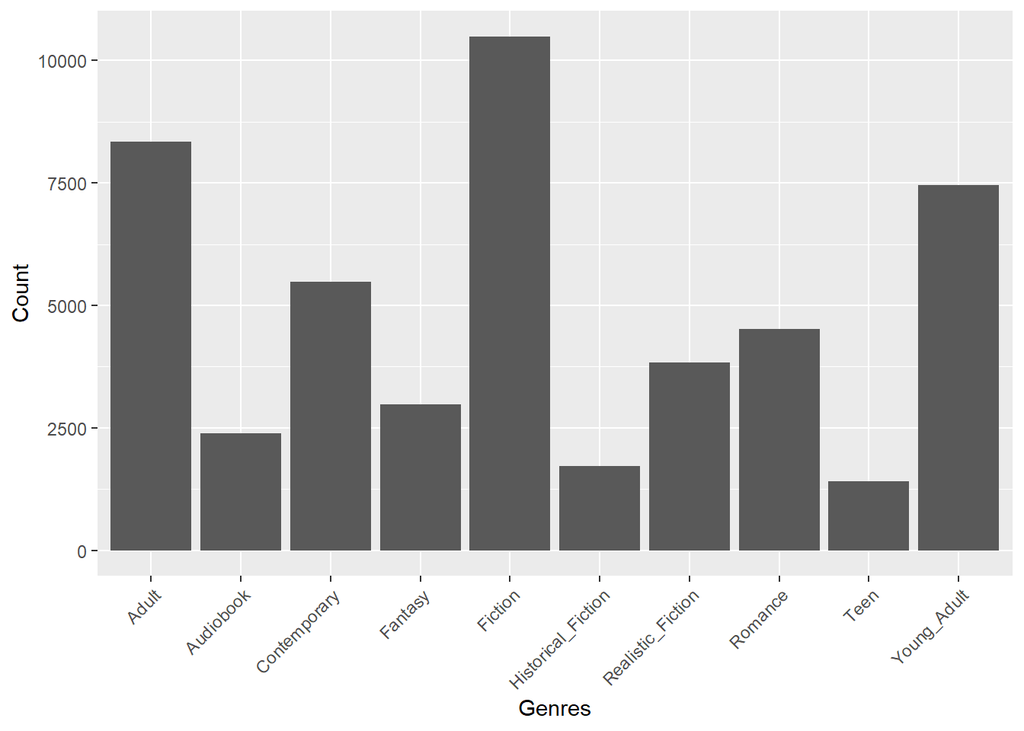

```r
top_10_genres <- genrecount_final %>%
  slice_max(order_by = Count, n = 10)

ggplot(top_10_genres, aes(x = Genres, y = Count)) +
  geom_col() +
  theme(axis.text.x = element_text(angle = 45, hjust = 1))
```

Fiction being the most banned book is best seen through the bar graph in relation to the other top 10 banned book genres. After fiction came adult and young adult books, which could be because of where they are being banned, such as in elementary schools. This would not be known by the data, but this at least shows us which genres were most banned.

### Descriptions

Next comes the descriptions of the books. With this, the data had to be cleaned in order to separate the words from one another. This allowed us to see which words appeared the most often, with the exeption that stopwords were removed.

```r
Descriptions_Unedited <- select(cleaned_data, Description)

desc_corpus <- Corpus(VectorSource(Descriptions_Unedited))
desc_lower <- tm_map(desc_corpus, content_transformer(tolower)) #making all of it lowercase
desc_punc <- tm_map(desc_lower, removePunctuation) #removing any punctuation
desc_num <- tm_map(desc_punc, removeNumbers) #removing numbers
desc_stop <- tm_map(desc_num, removeWords, stopwords("english")) #removing the typical English stopwords, such as a, and, and most pronouns
desc_clean <- tm_map(desc_stop, stripWhitespace) #this then removes any whitespace from the individual words.
```

After cleaning the data, the words were counted to then be put into the wordcloud.

```r
#Descriptions
desc_tdm <- TermDocumentMatrix(desc_clean)
m <- as.matrix(desc_tdm)
word_freqs <- sort(rowSums(m), decreasing = TRUE)
desc_df <- data.frame(word = names(word_freqs), freq = word_freqs)
```

```r
wordcloud2(desc_df, color = "blue")
```

[interactive chart not shown]

The word life appears to be the biggest word on the wordcloud, however, with the words by themselves, we do not know exactly why the word life appears the most in the descriptions of banned books. One word that may make more sense to find a bit bigger is the word sex, as this may be refering to sexuality and LGBTQ+ topics or adult novels which include the topic.

After looking at these, we decided to look to see which book was the most banned.

### What was the most banned book? - Alexis

This section was done by Alexis, who looked to see which book was the most banned, and eventually the frequency of the ban of the book.

```r
most_banned_book <- cleaned_data %>%
  count(Title, sort = TRUE) %>%
  slice(1) %>%
  pull(Title)

# Crank appears as most banned book
states_banned <- cleaned_data %>%
  filter(Title == most_banned_book) %>%
  distinct(State) %>%
  pull(State)

cat("Most banned book:", most_banned_book, "\n")
```

```
## Most banned book: Crank
```

```r
# Crank appears as most banned book
cat("States that banned it:\n")
```

```
## States that banned it:
```

```r
print(states_banned)
```

```
##  [1] "Florida"        "Nebraska"       "North Carolina" "North Dakota"
##  [5] "Oregon"         "Pennsylvania"   "South Carolina" "Texas"
##  [9] "Utah"           "Wyoming"        "Alaska"         "Georgia"
## [13] "Iowa"           "Maine"          "Maryland"       "Missouri"
## [17] "Tennessee"      "Virginia"       "Wisconsin"
```

```r
crank_data <- cleaned_data %>%
  filter(Title == most_banned_book)
```

#### Frequency of Crank’s ban (categorized by state political control)

After finding that Crank was the most banned book, we were interested in see the frequency of the ban, especially concerning the political control of the states.

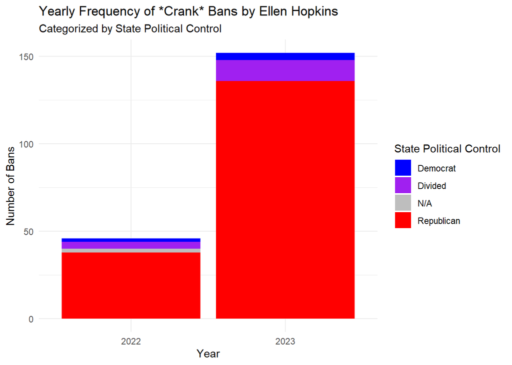

```r
#  frequency of bans by year
ggplot(crank_data, aes(x = factor(Year), fill = State.Control)) +
  geom_bar() +
   scale_fill_manual(
    values = c("Rep" = "red", "Dem" = "blue", "Divided" = "purple", "N/A" = "gray"),
    labels = c("Rep" = "Republican", "Dem" = "Democrat", "Divided" = "Divided")
  ) +
  labs(
    title = "Yearly Frequency of *Crank* Bans by Ellen Hopkins",
    subtitle = "Categorized by State Political Control",
    x = "Year", y = "Number of Bans",
    fill = "State Political Control"
  ) +
  theme_minimal()
```

We can see a dramatic increase in bans of the book “Crank” in 2023, the year after book banning bills were introduced.

#### Bans and Pending Bans of Crank in States and their Political Control

After looking at the party control of the state governments, it was an interesting topic to see the status of the ban of the book and the political control of the state.

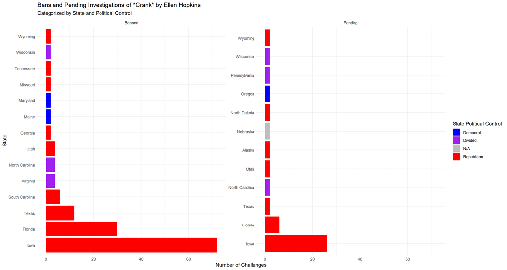

```r
# Step 1: Add Ban.Category
crank_data <- cleaned_data %>%
  filter(Title == "Crank") %>%
  mutate(Ban.Category = case_when(
    grepl("Pending Investigation", Ban.Status, ignore.case = TRUE) ~ "Pending",
    grepl("Banned", Ban.Status, ignore.case = TRUE) ~ "Banned",
    TRUE ~ "Other"
  ))

# Step 2: Summarize by State, Category, and Political Control
ban_combined <- crank_data %>%
  group_by(State, Ban.Category, State.Control) %>%
  summarise(Count = n(), .groups = "drop")

# Step 3: Plot
ggplot(ban_combined, aes(x = reorder(State, -Count), y = Count, fill = State.Control)) +
  geom_bar(stat = "identity", position = position_dodge(width = 0.8)) +
  facet_wrap(~Ban.Category, scales = "free_y") +
  coord_flip() +
  scale_fill_manual(
    values = c("Rep" = "red", "Dem" = "blue", "Divided" = "purple", "N/A" = "gray"),
    labels = c("Rep" = "Republican", "Dem" = "Democrat", "Divided" = "Divided", "N/A" = "N/A")
  ) +
  labs(
    title = "Bans and Pending Investigations of *Crank* by Ellen Hopkins",
    subtitle = "Categorized by State and Political Control",
    x = "State", y = "Number of Challenges",
    fill = "State Political Control"
  ) +
  theme_minimal()
```

We can see that Iowa and Florida were number 1 and 2 in banning this book and that some bans are still pending. Florida and Iowa being number 1 and 2 in banning this book will become relevant when we look at which states ban the most books.

### Book bans by Political Party

Before we look at the United States as a whole and then the top 2 states in banning books, we wanted to look at the idea of if different politically controlled states ban more or less books than one another.

```r
leg_control_counts <- cleaned_data %>%
  group_by(Year, State, Leg.Control) %>%
  summarise(Count = n(), .groups = 'drop') %>%
    mutate(Leg.Control = recode(Leg.Control,
                              "Dem" = "Democratic",
                              "Rep" = "Republican"))

leg_control_counts
```

```
## # A tibble: 94 × 4
##     Year State    Leg.Control Count
##    <int> <chr>    <chr>       <int>
##  1  2021 Alaska   Republican      1
##  2  2021 Arkansas Republican      1
##  3  2021 Florida  Republican    567
##  4  2021 Georgia  Republican     23
##  5  2021 Idaho    Republican     26
##  6  2021 Illinois Democratic      5
##  7  2021 Indiana  Republican     18
##  8  2021 Iowa     Republican      8
##  9  2021 Kansas   Republican     31
## 10  2021 Maine    Democratic      1
## # ℹ 84 more rows
```

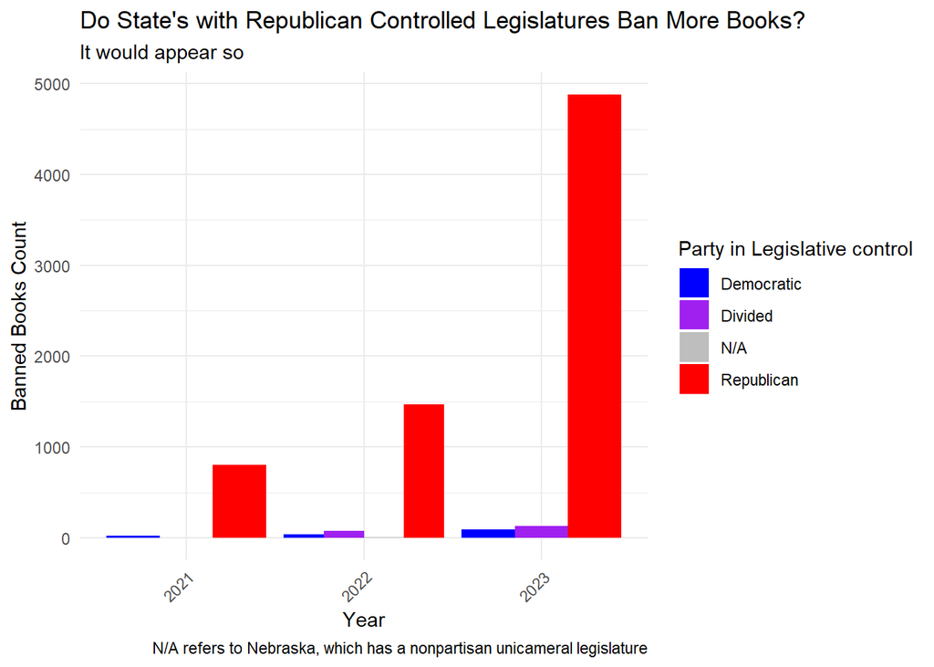

```r
ggplot(leg_control_counts, aes(x = factor(Year), y = Count, fill = Leg.Control)) +
  geom_bar(stat = "identity", position = "dodge") +
  scale_fill_manual(
    values = c(
      "Democratic" = "blue",
      "Republican" = "red",
      "Divided" = "purple",
      "N/A" = "gray"
    )
  ) +
  labs(
    title = "Do State's with Republican Controlled Legislatures Ban More Books?",
    subtitle = "It would appear so",
    caption = "N/A refers to Nebraska, which has a nonpartisan unicameral legislature",
    x = "Year",
    y = "Banned Books Count",
    fill = "Party in Legislative control"
  ) +
  theme_minimal() +
  theme(axis.text.x = element_text(angle= 45, hjust =1))
```

#### State by State - faceted

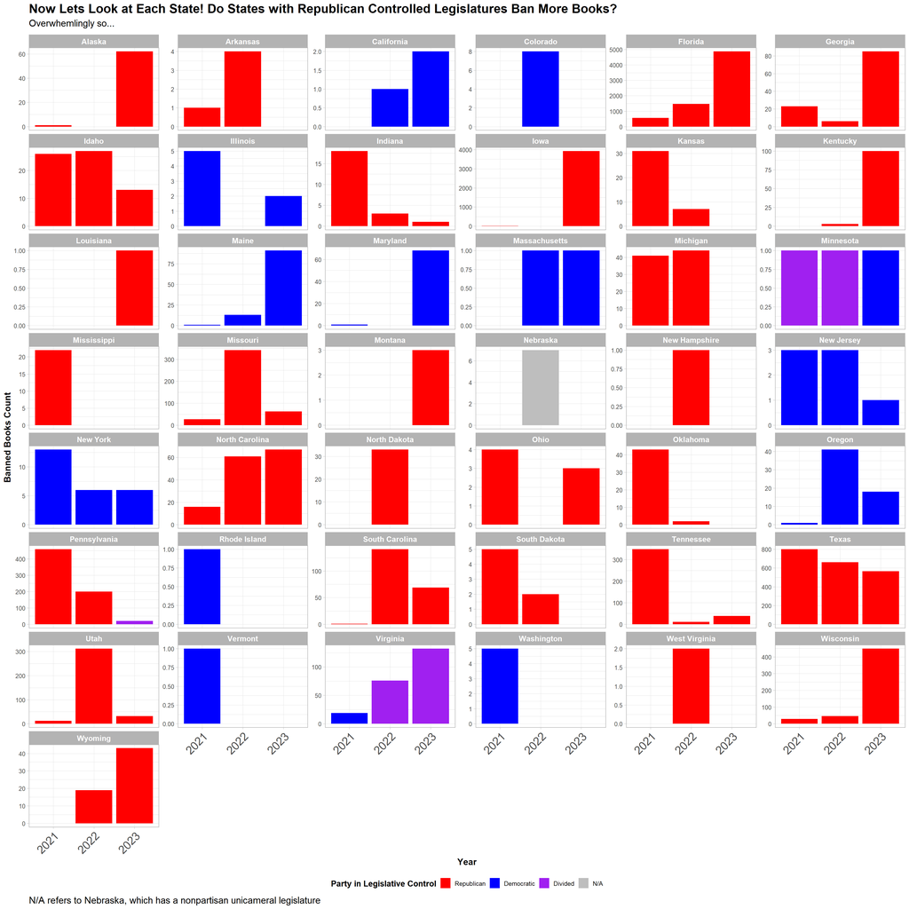

```r
# Faceted bar plot by state
ggplot(leg_control_counts, aes(x = factor(Year), y = Count, fill = Leg.Control)) +
  geom_bar(stat = "identity", position = "dodge") +
  facet_wrap(~ State, scales = "free_y", ncol = 6) +  # Facet by state
  scale_fill_manual(
    values = c(
      "Democratic" = "blue",
      "Republican" = "red",
      "Divided" = "purple",
      "N/A" = "gray"
    ),
    breaks = c("Republican", "Democratic", "Divided", "N/A")
  ) +
  labs(
    title = "Now Lets Look at Each State! Do States with Republican Controlled Legislatures Ban More Books?",
    subtitle = "Overwhemlingly so...",
    caption = "N/A refers to Nebraska, which has a nonpartisan unicameral legislature",
    x = "Year",
    y = "Banned Books Count",
    fill = "Party in Legislative Control"
  ) +
  theme_light(base_size = 12) +
     theme(
    plot.title = element_text(size = 20, face = "bold"),
    plot.subtitle = element_text(size = 15, margin = margin(b = 10)),
    plot.caption = element_text(size = 15, hjust = 0),
    axis.text.x = element_text(size = 18, angle = 45, hjust = 1),
    axis.title = element_text(face = "bold", size = 14),
    strip.text = element_text(size = 12, face = "bold"),
    legend.position = "bottom",
    legend.title = element_text(face = "bold", size = 13)
  )
```